# Day 8 Tasks & Activities

Halina Do-Linh

8/18/2021

## Data Visualization Worst

```r
space_launches <- read_csv(here("data", "space_launches.csv"), na = c("#VALUE!", " "))
```

Starting to wrangle

```r
space_lauches_w <- space_launches %>%
  group_by(agency_type, launch_year) %>%
  summarize(count = n()) %>%
  mutate(count = as.numeric(count))
```

Data Viz

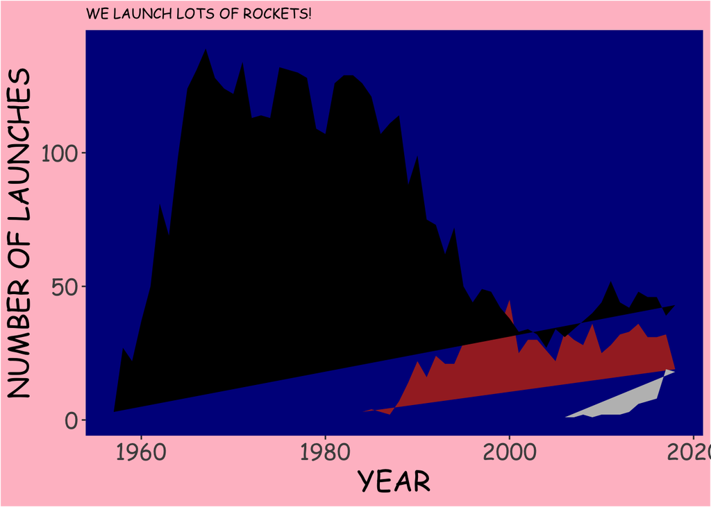

```r
ggplot(data = space_lauches_w, aes(x = launch_year, y = count)) +
  geom_polygon(aes(fill = agency_type), show.legend = FALSE) +
  labs(x = "YEAR", y = "NUMBER OF LAUNCHES", title = "WE LAUNCH LOTS OF ROCKETS!") +
  scale_fill_manual(values = c("brown", "gray", "black")) +
  theme(
    text = element_text(size = 20, family = "Comic Sans MS"),
    plot.title = element_text(size = 10),
    plot.background = element_rect("pink"),
    panel.grid = element_blank(),
    panel.background = element_rect("dark blue"),
  )
```

## Task 2: Data Wrangling

```r
sf_emissions <- read_csv(here("data", "SF_emissions.csv")) %>%
  clean_names()
```

Create a summary table of total annual greenhouse gas emissions (only from Emissions_mtCO2e column) by sector_general

```r
sf_emissions_sg <- sf_emissions %>%
  group_by(sector_general) %>%
  summarize(tot_ghg = sum(emissions_mt_co2e, na.rm = TRUE))
```

Create a summary table of total annual greenhouse gas emissions (only from Emissions_mtCO2e column) by year and commodity type

```r
sf_emissions_yc <- sf_emissions %>%
  group_by(calendar_year, commodity_type) %>%
  summarize(tot_ghg = sum(emissions_mt_co2e, na.rm = TRUE))
```

Create a subset of the data that only contains observations from 2005 on, only for observations where Sector_Detail2 contains the pattern “PG&E”, then limit to columns Calendar_Year, Sector_Detail2 and Emissions_mtCO2e.

```r
sf_emissions_pge <- sf_emissions %>%
  filter(calendar_year == 2005) %>%
  filter(str_detect(string = sector_detail2, pattern = "PG&E")) %>%
  select(c(calendar_year, sector_detail2, emissions_mt_co2e))
```

## Task 3

Create a finalized graph (as perfect as you can make it) using the San Francisco GHG emissions dataset. You get to choose what you want to visualize. You can pick which variables & observations you’re interested in. You may want to do some wrangling / summarizing first.

Once you’ve decided on what to plot, create the best graph that you can to communicate what’s going on with the data.

Once you’re done, drop your best graph (as a .png or .jpg) into the course Slack channel.

```r
sf_emissions_plot <- sf_emissions %>%
  select(c(calendar_year, sector_gpc, emissions_mt_co2e, commodity_type, sector_general, sector_gpc_detail)) %>%
  filter(str_detect(string = sector_gpc_detail, pattern = "Railways")) %>%
  group_by(commodity_type, calendar_year) %>%
  summarize(emissions_sum = sum(emissions_mt_co2e, na.rm = TRUE))
```

Making the plot

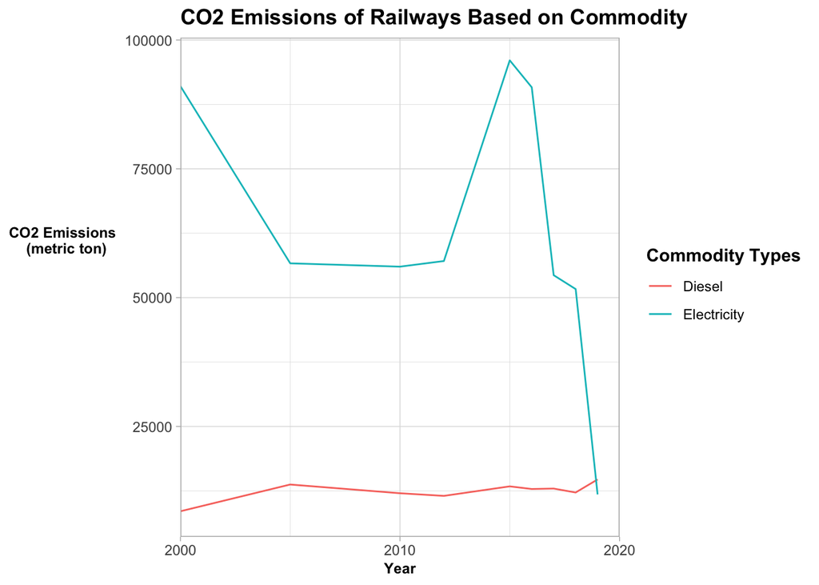

```r
ggplot(data = sf_emissions_plot, aes(x = calendar_year, y = emissions_sum)) +
  geom_line(aes(color = commodity_type, label = commodity_type)) +
  scale_x_continuous(breaks = c(2000, 2010, 2020),
                     limits = c(2000, 2020),
                     expand = c(0, 0)) +
  labs(x = "Year", y = "CO2 Emissions \n (metric ton)", title = "CO2 Emissions of Railways Based on Commodity", color = "Commodity Types", size = 9) +
  theme_light() +
  theme(
      title = element_text(face = "bold"),
      axis.title.y = element_text(angle = 360, face = "bold", vjust = 0.6, size = 9),
      axis.title.x = element_text(size = 9)
    )
```

```r
#  geom_dl(aes(label = commodity_type), method = "last.points", hjust = -10) +
# geom_dl(aes(label = State), method = list(dl.combine("first.points", "last.points")), cex = 0.8)
```

## Alt Text Practice

```r
library(tidyverse)
library(palmerpenguins)

ggplot(penguins, aes(x = body_mass_g)) +
  geom_histogram() +
  facet_wrap(~species)
```

[output not shown]